# Linear Regression II - model bashing

Estimation, prediction and model checking

Timothy Hofer

thofer@umich.edu

University of Michigan

September 16, 2026

# Review

*models, coefficients and the assumptions of linear regression*

## What does quantitative analysis involve?

#### Building models

$$Data_i = model + error_i$$

#### Everything is regression

#### The 3 general types/purpose of building models are generalizing…

- from sample to population
- from treatment to control group
- from observed measurement to the thing you want to measure

## Linear regression: the prototype

$$\begin{aligned}
y_i&=\boldsymbol{x_i^\top \beta}+\epsilon_i \\
&\text{Where }\epsilon \text{ has mean}=0, \text{and variance }=\sigma^2
\end{aligned}$$

Another way you represent the linear regression model specifies a linear function for the conditional mean and a probability distribution function (PDF)

$$\begin{aligned}
\hat \mu_i&=\boldsymbol{x_i^\top\beta} \\
y_i &\sim N(\hat\mu_i,\sigma)
\end{aligned}$$

We will use this latter form when we have to generalize the linear regression models to fit other types of data and error structures. (most immediately logistic regression)

# Estimation

*a brief detour: frequentist and Bayesian frameworks* (Biostat II lecture)

# Frequentist and Bayesian

**Frequentist**  
Probability with which data sets like the observed would appear given the parameters (& model)

$$P(D|Parameters)$$

**Bayesian**  
Probability describes uncertainty about the parameters given the observed data (& model)

$$P(Parameters|D)$$

[figure not shown]

## Frequentist estimation - Maximum likelihood

- Treat the parameters as fixed and the data as random
- Procedure
  - Pick some parameter values $y=a + b*x$
  - Calculate the probability of the data $P(data | parameters)$
  - Pick some other values
  - Calculate the probability of the data
  - Keep going until you find the maximum probability

## Probability of the data

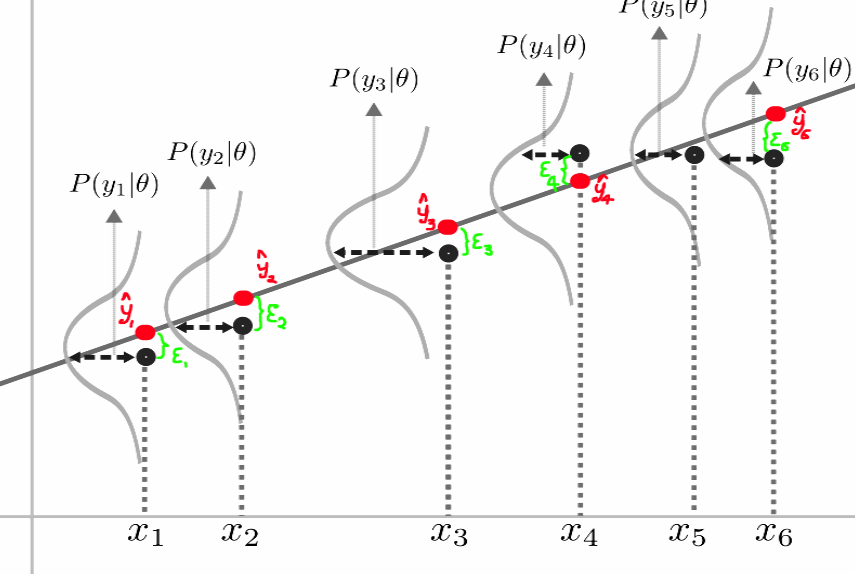

## Likelihood function

for the probability of the data

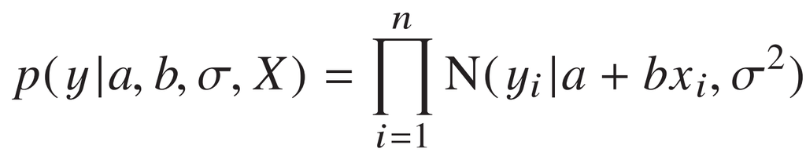

- Since the probability of each point is $<1$ the product gets really really small
- To simplify things and turn the equation into a sum we take the log, thus giving the log likelihood. (a large negative number)
- The larger the log likelihood (closer to 0) the better the model fits

## Likelihood surface

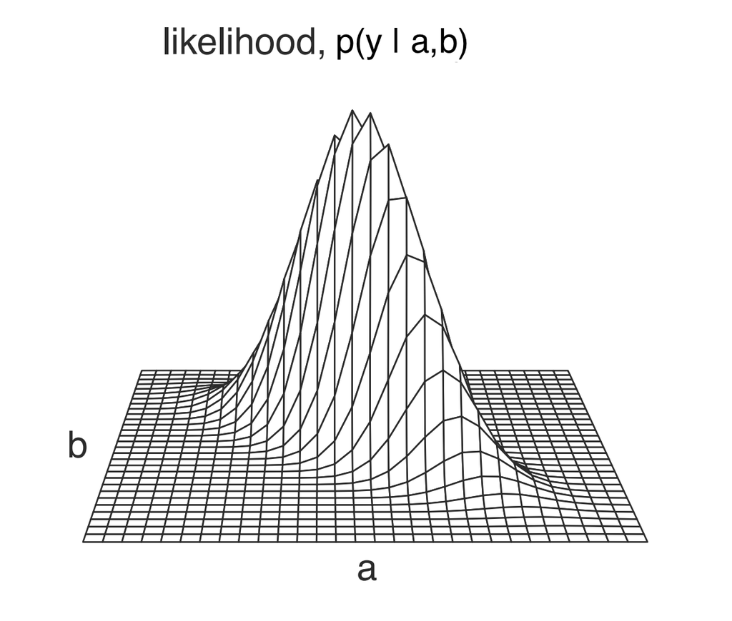

## Linear regression

- For linear regression you can solve the log likelihood function and you get the formula for the **least-squares** solution for minimizing the vertical errors from a line.
- So **least squares is a special case of the maximum likelihood method**
- All other types of regression require iterating through parameter estimates to maximise the likelihood

# 2. Prediction

*once you have a model, prediction plays a major role in describing and assessing it*

## Coefficients are predictions

#### Interpreting coefficients - predictive vs counterfactual

- **predictive:** a comparison of how the outcome varies on average when two groups of observations that differ by 1 in a predictor but are identical in the other variables.
- **counterfactual:** expressed in terms of changes within individuals - an interpretation that requires causal inference

#### Constant or varying coefficients

- fixed - the coefficient is constrained to have one value *for all groups of observations*
- varying - the coefficient is allowed to vary for different groups (**interactions** are the most familiar way to do this)

## Exploring your data and prediction is model checking

- Use graphs in lots of exploratory data analyses to find unexpected patterns and observations.
- Graph your predictions (Section 11.1.4) thinking about whether the patterns make sense given content knowledge.
- Make multivariate predictions (across two or more variables) to see if the model predictions have hidden or obscured anomalous patterns.

## Plotting data and predictions of a fitted model

#### Several types of prediction

- simple point prediction for a new value (ignores uncertainty)
- linear predictor with uncertainty (uncertainty about conditional mean or expected value)
- predictive distribution of new observations (forecasting)

**Point prediction**

```stata
qui sysuse auto
qui regress mpg weight
di "A hypothetical 4000 pound car gets " `:di %3.2f _b[_cons]+_b[weight]*4000' " mpg"
```

```
A hypothetical 4000 pound car gets 15.41 mpg
```